# WIWA gaiah analysis

Eric C. Anderson

June 1, 2016

## Preliminaries

First we will load all the libraries that we need.

```r
library(raster)  # call this before dplyr so it doesn't mask select
library(dplyr)
library(stringr)
library(ggplot2)
library(gaiah)
library(parallel)
```

And after that we have a block where we define variables that tell us whether to recompute values from scratch or to use a few cached ones.

```r
COMPUTE_ISO_POSTERIORS <- FALSE
```

## Prepare all the rasters

Just some machinations to get `Mgen`, `Miso`, and `Mhab`.

### Computing isotope posteriors

First we compute all the isotope-based posterior surfaces for each reference bird using a Leave-one-out procedure. This defines `Miso`.

```r
ref_birds <- breeding_wiwa_isotopes
if(COMPUTE_ISO_POSTERIORS == TRUE) {
  isotope_ref_bird_results <- isotope_posterior_probs(isoscape = isomap_job54152_prediction,
                                                    ref_birds = ref_birds,
                                                    isoscape_pred_column = "predkrig",
                                                    isoscape_sd_column = "stdkrig",
                                                    self_assign = TRUE)
  #save(isotope_ref_bird_results, file = "outputs/isotope_ref_bird_results.rda", compress = "xz")
} else {
  load("../outputs/isotope_ref_bird_results.rda")
}
# clip the isotope posteriors to the known breeding range and normalize again
# I should rewrite the function to do this if we have the breeding range...maybe...
# also, at this point I am going to get a simple list of rasters
Miso <- lapply(isotope_ref_bird_results$loo_results, function(y) {
  x <- y$posterior_probs
  x * wiwa_breed / raster::cellStats(x * wiwa_breed, sum)
})
```

### Get and process the genetics posteriors

We have the posteriors to each of the genetic groups for each of the birds. We are going to take those and then smear them over the geographic extent of the each genetic group for each bird. This defines `Mgen`.

```r
Mgen <- genetic_posteriors2rasters(breeding_wiwa_genetic_posteriors, genetic_regions)  # this takes about 25 seconds
```

### Load up the habitat quality raster

This is part of the `gaiah` package. We get it and then we clip it to the breeding range and make a version that is normalized. This makes `Mhab` and `Mhab_norm`. For most dowstream analyses we are going to want to use `Mhab_norm`.

```r
Mhab <- wiwa_habitat_unclipped * wiwa_breed  # make sure to clip it with the known breeding range.
Mhab_norm <- Mhab / raster::cellStats(Mhab, stat = sum)  # and for later analyses, treat these as posterior probs
```

### Finally some fiddly bookeeping

Here we only keep birds that have both isotope and genetic data. The result of this is `kbirds`, our master data frame of the birds that we will be using here. We also have to keep track of which groups these birds are in so we end up using the short population names and fiddling with that here. Also we turn `Miso` and `Mgen` into `rasterStacks`.

```r
# I want to retain only the birds that appear both in Mgen and Miso, and I
# want to order them so that they are all together from different locations
keepers <- intersect(names(Miso), names(Mgen))
# here we input the genetic regions for those short pops.  I get these from the repunits
# file from the wiwa-popgen repo.  Ultimately I will want to have these with the data from the get-go
spr <- read.table(textConnection("ShortPop  region
                                 wAKDE AK.EastBC.AB
                                 wAKYA AK.EastBC.AB
                                 wAKUG AK.EastBC.AB
                                 wAKJU AK.EastBC.AB
                                 wABCA AK.EastBC.AB
                                 wBCMH AK.EastBC.AB
                                 wWADA Wa.To.NorCalCoast
                                 wORHA Wa.To.NorCalCoast
                                 wORMB Wa.To.NorCalCoast
                                 wCAEU Wa.To.NorCalCoast
                                 wCAHM CentCalCoast
                                 wCABS CentCalCoast
                                 wCASL CentCalCoast
                                 wCATE CalSierra
                                 wCACL CalSierra
                                 wCAHU CalSierra
                                 wMTHM Basin.Rockies
                                 wOREL Basin.Rockies
                                 wCOPP Basin.Rockies
                                 wCOGM Basin.Rockies
                                 eQCCM Eastern
                                 eONHI Eastern
                                 eNBFR Eastern
                                 "), header = TRUE, stringsAsFactors = FALSE)
kbirds <- ref_birds %>%
  filter(ID %in% keepers) %>%  # the names got mangled so I have to do this
  mutate(ShortPop = str_replace_all(Short_Name, "[0-9]", "")) %>%
  left_join(spr) %>%
  arrange(region, ShortPop, Short_Name) %>%
  dplyr::select(ID, region, ShortPop, Short_Name, lat, long, everything())
# Now, I think that it is just going to be better to use the Short_Names for all of these
# (at least it will be easier to think about and check everything).  So do the following:
Miso <- Miso[kbirds$ID]
names(Miso) <- kbirds$Short_Name
Mgen <- Mgen[kbirds$ID]
names(Mgen) <- kbirds$Short_Name
# and, in fact, it will be nice to make these RasterStacks, now that they are in the right
# order
Miso <- raster::stack(Miso)
Mgen <- raster::stack(Mgen)
```

## Play around with combinging data types

This is just to have a quick look at what happens when we combine data types. Here we just use equal weighting.

```r
Combo <- comboize(Mgen, Miso, Mhab_norm, 1, 1, 1)
```

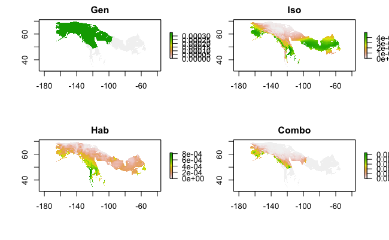

```r
par(mfrow = c(2,2))
plot(Mgen[[100]], main = "Gen")
plot(Miso[[100]], main = "Iso")
plot(Mhab_norm, main = "Hab")
plot(Combo[[100]], main = "Combo")
```

## Computing min-hpd-areas

We can compute all the min-hpd-areas like this

```r
mhia <- min_hpd_inc_area_df(kbirds, Combo)
```

But what we really would like to do is compute those values for different betas. I am going to fix beta_gen at 1 and then explore a few different values for the others. This is set to not recompute at the moment. Just get the stored results

```r
griddy <- c(0, 0.33, 0.66, 1.0, 1.33, 1.66, 2.0, 2.5)
names(griddy) <- griddy

out <- mclapply(c("1.0" = 1.0), function(bgen) {
  mclapply(griddy, function(biso) {
    mclapply(griddy, function(bhab) {
      print(c(bgen, biso, bhab))
      min_hpd_inc_area_df(kbirds, comboize(Mgen, Miso, Mhab_norm, beta_gen = bgen, beta_iso = biso, beta_hab = bhab))$area
    }) %>%
      bind_rows(.id = "beta_hab")
  }) %>%
    bind_rows(.id = "beta_iso")
}) %>% bind_rows(.id = "beta_gen")

saveRDS(out, file = "64_vals.rds", compress = "xz")
```

Then have a look at that over the different regions.

```r
region_means <- kbirds %>%
  select(region, Short_Name) %>%
  left_join(., out) %>%
  group_by(region, beta_gen, beta_iso, beta_hab) %>%
  summarize(mean_area = mean(min_hpd_area),
            trimmed10_mean_area = mean(min_hpd_area, trim = 0.10)) %>%
  ungroup() %>% arrange(region, mean_area)
```

And now we will want to make some plots that show the influence of the exponent: Here it is using all of the data:

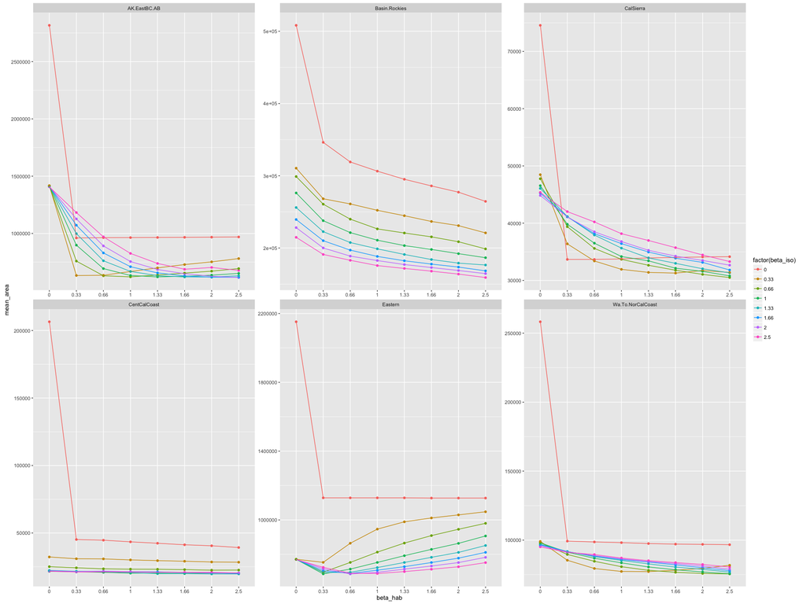

```r
ggplot(region_means, aes(x = beta_hab, y = mean_area, colour = factor(beta_iso), group = factor(beta_iso))) +
  geom_point() +
  geom_line() +
  facet_wrap(~ region, scales = "free")
```

Here it is using a trimmed mean with the middle 80% of the observations.

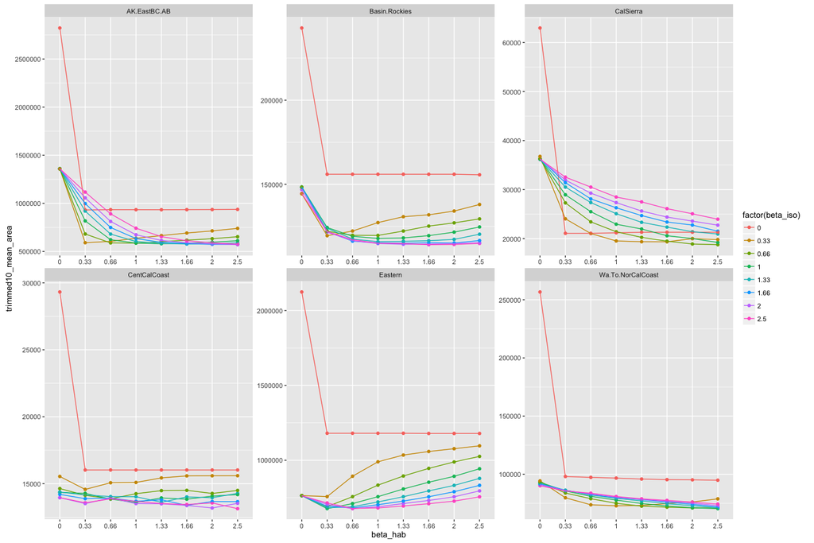

```r
ggplot(region_means, aes(x = beta_hab, y = trimmed10_mean_area, colour = factor(beta_iso), group = factor(beta_iso))) +
  geom_point() +
  geom_line() +
  facet_wrap(~ region, scales = "free")
```

### Gonna look at some plots for individuals

I want to plot individual min-hpd-areas. I think that I should take Mhab as the “base” case. And then I should see what happens when you add either genetics or isotopes.

```r
out2 <- kbirds %>%
  select(region, Short_Name) %>%
  left_join(., out)

hab_only <- out2 %>%
  filter(beta_iso == 0, beta_gen == 0, beta_hab == 1)
hab_iso <- out2 %>% filter(beta_hab == 1, beta_iso == 1, beta_gen == 0)
hab_gen <- out2 %>% filter(beta_hab == 1, beta_iso == 0, beta_gen == 1)
gen_iso <- out2 %>% filter(beta_hab == 0, beta_iso == 1, beta_gen == 1)
hab_gen_iso <- out2 %>% filter(beta_hab == 1, beta_iso == 1, beta_gen == 1)

tmp <- list(hab_only = hab_only, hab_iso = hab_iso, hab_gen = hab_gen, gen_iso = gen_iso, hab_gen_iso = hab_gen_iso) %>%
  bind_rows(.id = "info_type") %>%
  select(-contains("beta")) %>%
  tidyr::spread(., key = info_type, value = min_hpd_area)

ggplot(tmp, aes(x = hab_iso, y = hab_gen, colour = region)) +
  geom_point() +
  geom_abline(intercept = 0, slope = 1) +
  facet_wrap(~ region)


ggplot(tmp, aes(x = gen_iso, y = hab_gen_iso, colour = region)) +
  geom_point() +
  geom_abline(intercept = 0, slope = 1) +
  facet_wrap(~ region)
```

## Make some plots

We want some plots that show the posteriors and the true locations of the reference birds. First define a function, `quickie_plots` that makes large pages of plots. We won’t evaluate this but you can see the results in ``outputs` from previous runs.

```r
# bird is the Short_Name of the bird
quickie_plots <- function(bird, Miso, Mgen, Mhab, kbirds) {
  lat <- kbirds$lat[kbirds$Short_Name == bird]
  long <- kbirds$long[kbirds$Short_Name == bird]
  reg <- kbirds$region[kbirds$Short_Name == bird]

  plot(Mgen[[bird]],  main = paste("Genetics:", bird, reg))
  points(long, lat, pch = 18, col = 'red', cex = 1.5)

  plot(Miso[[bird]],  main = paste("Isotopes:", bird, reg))
  points(long, lat, pch = 18, col = 'red', cex = 1.5)

  plot(Mhab,  main = paste("Habitat:", bird, reg))
  points(long, lat, pch = 18, col = 'red', cex = 1.5)
}

bird_name_mat <- matrix(kbirds$Short_Name, nrow = 36)
for(i in 1:ncol(bird_name_mat)) {
  pdf(file = paste("outputs/known_origin_raster_", i, ".pdf", sep = ""), height = 162, width = 11)
  par(mfrow = c(36,3))
  lapply(bird_name_mat[, i], function(x) quickie_plots(x, Miso, Mgen, Mhab, kbirds))
  dev.off()
  message(paste("Done with", i))
}
```

## Computation of great circle distances and posterior means of GC distances

First, we make a `rasterStack` that gives the great circle distance between each reference birds true location and every cell in the raster. This makes the rasterStack, `GCD`.

```r
GCD <- lapply(1:nrow(kbirds), function(i)
    great_circle_raster(wiwa_breed, kbirds$lat[i], kbirds$long[i])
  )
names(GCD) <- kbirds$Short_Name

GCD <- raster::stack(GCD)
```

And now, using that we can compute the posterior mean great circle distances between then inferred origins and the true sampling location. We do this for genetics, isotopes, and habitat, and we add those posterior mean distances to `kbirds`

```r
genpmgc <- raster::cellStats(Mgen * GCD, stat = sum)
isopmgc <- raster::cellStats(Miso * GCD, stat = sum)
habpmgc <- cellStats(GCD * Mhab_norm, stat = sum)
names(habpmgc) <- names(GCD)

# and just quickly, let us add that to our kbirds data frame
dist_df <- kbirds
dist_df$gc_iso <- isopmgc[dist_df$Short_Name]
dist_df$gc_gen <- genpmgc[dist_df$Short_Name]
dist_df$gc_hab <- habpmgc[dist_df$Short_Name]
```

## Summarise posterior mean GC distances

We can make some violin plots to show how the different methods do on birds from different known locations.

```r
# put it into long format
dist_tidy <- dist_df %>%
  tidyr::gather(., key = "data_type", value = "post_mean_gc_dist", gc_iso:gc_hab)

ggplot(dist_tidy, aes(y = post_mean_gc_dist, x =  data_type, fill = data_type)) +
  geom_violin() +
  facet_wrap(~ region) +
  coord_flip()
```

### Exploring the space of $\beta_\mathrm{iso}$ and $\beta_\mathrm{hab}$

For each value of pair of values of $\beta_\mathrm{iso}$ and $\beta_\mathrm{hab}$ between 0 and 1 (or maybe 1.5 if it will be better to crank them up more) I want to see what the mean of the posterior mean great circle distances are for each of the different groups. We will be able to plot this is a contour. So, first get a function that takes the two beta values and returns a data frame of the resulting mean posterior great circle values.

```r
gcpms_from_betas <- function(biso = 1, bhab = 1) {
  Mcombo <- comboize(biso, bhab)
  pmgc <- cellStats(GCD * Mcombo, stat = sum)
  data_frame(Short_Name = names(pmgc), beta_iso = biso, beta_hab = bhab, pmgc = pmgc) %>%
    left_join(kbirds %>% select(region, Short_Name), .)
}
```

And then we just lapply over a bunch of beta values and bind all the rows together in the end. But don’t evaluate this. Takes too long.

```r
big_beta_frame <- lapply(seq(0, 1.5, by = 0.1), function(i) {
  lapply(seq(0, 1.5, by = 0.1), function(h) {
    print(c(i, h))
    gcpms_from_betas(i, h)
  }) %>% bind_rows()
}) %>% bind_rows()
```

And now we will summarise those into means for each region and make a contour plot of it.

```r
bbsum <- big_beta_frame %>%
  group_by(region, beta_iso, beta_hab) %>%
  summarise(mean_pmgc_dist = mean(pmgc))

ggplot(bbsum, aes(x = beta_iso, y = beta_hab, z = mean_pmgc_dist)) +
  geom_contour() +
  facet_wrap(~ region)
```

## Exploring a different accuracy measure

We might be able to do something with the the inclusion status (and the sizes) of different HPD credible intervals. In order to do this we will want to have a function that takes a posterior probability raster and then computes the cumulative posterior prob at each cell given that they are sorted in descending order of posterior probability.

```r
#' finds the cumulative posterior probability of each cell for HPD calculation
#'
#' @param B a raster of posterior probs
hpd_cumul <- function(B) {
  ord <- order(values(B), decreasing = TRUE, na.last = TRUE)
  cumul = cumsum(values(B)[ord])
  values(B)[ord] <- cumul
  B
}
```

See how this works, now. Here are the cumulative values:

```r
Mcombo <- comboize(1.0, 1.0)
plot(hpd_cumul(Mcombo[[1]]))
```

If we want to find the 50% HPD credible region we can do like this.

```r
plot(hpd_cumul(Mcombo[[1]]) < 0.5 )
```

and if we wanted to, for instance find the area of the 50% HPD credible interval, we would di this:

```r
cellStats((hpd_cumul(Mcombo[[1]]) < 0.5) * area(Mcombo[[1]]), stat = sum)
```

Let’s just try that simply

```r
#' compute the smallest area of an HPD credible set that includes the true bird location
#'
#' This function computes the area of the HPD credible set that is as small as possible
#' but just barely includes the cell with the true location (or, if the true location is not
#' actually inluded in the range map, we use the closest cell on the range map to the true
#' location)
#' @param M the posterior surface matrix
#' @param lat the true latitude
#' @param long the true longitude
min_hpd_inclusion_area <- function(M, lat, long) {
  hpc <- hpd_cumul(M)
  gcd <- great_circle_raster(M, lat, long)

  # here are the distances from the point to non-NA cells
  dd <- gcd * (hpc > 0)

  # here is the minimum distance to a nonNA cell
  mindist <- cellStats(dd, min, na.rm = TRUE)

  # here is a mask that picks out the closest cell(s)
  cc <- abs(dd - mindist) < 10-8  # don't test equality of numerics...

  # here is the hpd value at that point
  hpd_at_ll <- cellStats(cc * hpc, sum, na.rm = TRUE) / cellStats(cc, sum, na.rm = TRUE)

  # now, get the area of the hpd_at_ll  HPD CI
  hpc_area <- cellStats( (hpc < (hpd_at_ll + 1e-9)) * area(hpc), stat = sum, na.rm = TRUE)

  # return both the cumulative prob and the cumulative HPD area
  list(area = hpc_area, cumul_prob = hpd_at_ll)
}
```

Now that we have that defined, let’s see if we can add it to kbirds

```r
Mcombo1_1 <- comboize(1.0, 1.0)  # just go for the equal weighting
lats <- kbirds$lat
longs <- kbirds$long
names(lats) <- kbirds$Short_Name
names(longs) <- kbirds$Short_Name
birds <- kbirds$Short_Name
names(birds) <- birds

hpd_areas_1_1 <- unlist(lapply(birds, function(b) {min_hpd_inclusion_area(Mcombo1_1[[b]], lats[b], longs[b])$area}))

hpd_areas_iso <- unlist(lapply(birds, function(b) {min_hpd_inclusion_area(Miso[[b]], lats[b], longs[b])$area}))

hpd_areas_hab <- unlist(lapply(birds, function(b) {min_hpd_inclusion_area(Mhab, lats[b], longs[b])$area}))

Mgen_iso <- comboize(1.0, 0.0)
hpd_areas_gen_iso <- unlist(lapply(birds, function(b) {min_hpd_inclusion_area(Mgen_iso[[b]], lats[b], longs[b])$area}))

Mgen_hab <- comboize(0.0, 1.0)
hpd_areas_gen_hab <- unlist(lapply(birds, function(b) {min_hpd_inclusion_area(Mgen_hab[[b]], lats[b], longs[b])$area}))

kb_areas <- data_frame(hpd_areas_1_1, hpd_areas_iso, hpd_areas_hab, hpd_areas_gen_iso, hpd_areas_gen_hab) %>%
  setNames(c("hpd_areas_1_1", "hpd_areas_iso", "hpd_areas_hab", "hpd_areas_gen_iso", "hpd_areas_gen_hab")) %>%
  bind_cols(kbirds, .)
```

Now we can plot those things. How about some scatters?

```r
ggplot(kb_areas, aes(x = hpd_areas_1_1, y = hpd_areas_gen_iso, colour = region)) +
  geom_point() +
  geom_abline(intercept = 0, slope = 1, linetype = "dashed") +
  facet_wrap(~ region, ncol = 2, scales = "free")
```